# Prior-aware calibration of OpenSpliceAI-style splice-site prediction under genome-level class imbalance

Anonymous submission

## Abstract

Deep learning splice-site predictors are usually evaluated as detection systems, although their output scores are often interpreted as probabilities. These objectives differ in per-nucleotide prediction, where acceptor and donor sites are extremely rare relative to non-splice positions. We evaluate prior-aware probability calibration for focal-loss OpenSpliceAI-style models trained on human GRCh38/MANE annotations with 80- and 400-nt sequence context. Using true pre-softmax logits, we compare uncalibrated predictions, fixed global temperature scaling, unweighted vector temperature scaling, genome-prior-weighted vector temperature scaling, and a locally implemented OpenSpliceAI-style class-wise vector-temperature baseline. Across two independently trained flank-400 models, streaming evaluation over five test chromosomes (416,140,000 positions per model) reproduced the calibration ordering: OpenSpliceAI-style vector temperature scaling had the lowest pooled ECE and NLL, while genome-prior-weighted vector scaling also improved both metrics. Detection and calibrated probability estimation should therefore be evaluated separately, and splice-site probabilities should be interpreted only relative to an explicit target population.

## Introduction

RNA splicing is a central mechanism by which eukaryotic cells generate transcript diversity from genomic sequence. Alternative splicing is regulated by combinations of cis-regulatory motifs, transcript structure, splice-site strength, and cellular context. Early computational work on the “splicing code” demonstrated that combinations of RNA features can predict tissue-dependent splicing patterns, establishing splicing prediction as a problem of learning regulatory sequence logic rather than detecting canonical splice motifs alone (Barash et al. 2010). Competitive models later made the dependence of splice-site usage on neighboring sites explicit (Bretschneider et al. 2018).

Deep learning subsequently shifted splice prediction from hand-engineered regulatory features toward direct sequence-to-sequence prediction. SpliceAI introduced a residual convolutional architecture that predicts whether each position in a pre-mRNA sequence is an acceptor, donor, or neither (Jaganathan et al. 2019). Pangolin extended sequence-based prediction toward tissue-aware splice-site strength (Zeng and Li 2022). OpenSpliceAI later provided a modular PyTorch implementation supporting retraining, transfer learning, prediction, variant analysis, and post-hoc calibration (Chao et al. 2025).

Most splice-site evaluations emphasize detection: whether true acceptor and donor sites receive higher scores than non-splice positions. Detection metrics are appropriate for annotation, variant prioritization, and candidate discovery. However, model scores are also commonly interpreted as confidence estimates. Such an interpretation requires calibration: among predictions assigned a particular probability, the empirical event frequency should be similar.

Calibration is especially sensitive to the evaluation population in per-nucleotide splice-site prediction. Nearly all evaluated positions are non-splice, whereas acceptor and donor sites are rare. Efficient evaluation caches often retain every splice-site positive but subsample non-splice positions, creating a splice-enriched distribution. Calibration fitted or evaluated on this sampled distribution estimates probabilities for that distribution, not automatically for the full target-position population.

This distinction separates two objectives. Detection asks whether true splice sites are ranked above non-splice positions. Calibration asks whether predicted probabilities match observed frequencies under a specified target population and class prior. A model may perform extremely well at detection while remaining unsuitable as a probability estimator under another prior.

We study this distinction using focal-loss OpenSpliceAI-style models with 80- and 400-nt context. Flank-400 is the primary experiment; flank-80 provides a controlled weaker-context comparison. We extract true pre-softmax logits and compare uncalibrated scores, fixed global temperature scaling, unweighted vector scaling, genome-prior weighted vector scaling, and a locally implemented OpenSpliceAI-style class-wise vector-temperature baseline. We evaluate probability quality using ECE, NLL, reliability diagrams, bootstrap resampling, prior-sensitivity analysis, and exhaustive streaming across five test chromosomes in two independently trained flank-400 models. Detection is evaluated separately using acceptor/donor AUPRC and threshold precision-recall.

Our contributions are:

# Related Work

## Splicing codes and feature-based prediction

Early computational models of splicing framed alternative splicing as a regulatory code. These approaches combined cis-regulatory motifs, conservation, exon and intron structure, and tissue context to predict exon inclusion or tissue-dependent splicing changes. They established that splicing regulation depends on combinations of sequence and transcript features, but their scope was constrained by manually designed representations.

## Deep learning for splice-site prediction

SpliceAI formulated splice-site prediction as per-position three-class classification and showed that long primary-sequence context can support accurate splice-site and variant-effect prediction (Jaganathan et al. 2019). Related deep models address competitive splice-site selection (Bretschneider et al. 2018) and tissue-aware splice strength (Zeng and Li 2022). This sequence-to-sequence target is also used here. Our objective is not to propose a new detector or claim state-of-the-art detection; it is to evaluate whether the detector’s output scale can be interpreted probabilistically under a declared target distribution.

## OpenSpliceAI and calibration

OpenSpliceAI provides a trainable PyTorch implementation of the SpliceAI framework and includes class-wise temperature calibration (Chao et al. 2025). Its calibration analysis motivates a further question: calibration is defined relative to a dataset and is not guaranteed to transfer when the class prior, label definition, or downstream population changes. We therefore compare an OpenSpliceAI-style class-wise vector-temperature baseline with explicitly prior-weighted calibration and evaluate the resulting probabilities under stated target priors.

## Neural-network probability calibration under imbalance

High predictive accuracy does not guarantee calibrated probabilities (Guo et al. 2017). Temperature scaling rescales frozen model logits after training, while vector temperature scaling permits class-specific rescaling; more flexible multiclass maps, such as Dirichlet calibration, further illustrate that calibration is a separate post-hoc modeling problem (Kull et al. 2019). Under extreme imbalance, both fitting and evaluation depend on the represented class prior. Retaining positives while subsampling negatives changes empirical frequencies, so unweighted calibration on a splice-enriched cache answers a different probability question from calibration under the full target-position prior.

## Gap addressed by this work

Prior splice-site prediction work primarily emphasizes whether models identify or rank splice sites accurately. We focus instead on how the target prior changes probability interpretation. Detection and calibration are reported separately, and no claim is made that the proposed evaluation framework improves the underlying detector.

# Methods

## Models and prediction task

We evaluated OpenSpliceAI-style per-position classifiers trained on human GRCh38 sequence (Schneider et al. 2017) and MANE canonical splice-site annotations (Morales et al. 2022). At each evaluated position, the model predicts one of three classes: non-splice, acceptor, or donor. Focal loss was used to address the extreme imbalance between non-splice and splice-site labels (Lin et al. 2017).

The primary flank-400 model was the validation-selected seed-11/epoch-11 checkpoint:

`results/best_models/flank400_focal_epoch11_best.pt`

The independent replication was the validation-selected seed-23/epoch-14 checkpoint:

`results/best_models/flank400_seed23_focal_epoch14_best.pt`

The controlled context comparison used `results/best_models/flank80_focal_epoch2_best.pt`. The two flank-400 models were trained independently and selected within seed using validation performance. The flank-80/flank-400 comparison is descriptive because context, seed, and selected epoch differ.

## Evaluation data and sampled caches

The flank-400 model used:

- `data/processed_h5_flank400/dataset_validation.h5`
- `data/processed_h5_flank400/dataset_test.h5`

The flank-80 model used the corresponding files under `data/processed_h5/`. Both context settings represent the same underlying GRCh38/MANE gene and transcript records with different input context.

Across the complete test H5, 416,160,000 positions were evaluated: 106,088 splice-site positives and 416,053,912 non-splice positions. Repeated calibration analysis used caches containing every positive and a reservoir sample of 500,000 non-splice positions. Each test cache therefore contained 606,088 positions: 500,000 non-splice positions, 53,024 acceptors, and 53,064 donors.

The authoritative flank-400 sampled caches were:

- `results/logit_cache_flank400_seed11_epoch11/validation_sampled_logits.npz`
- `results/logit_cache_flank400_seed11_epoch11/test_sampled_logits.npz`
- `results/logit_cache_flank400_seed23_epoch14/validation_sampled_logits.npz`
- `results/logit_cache_flank400_seed23_epoch14/test_sampled_logits.npz`

The flank-80 caches were stored under `results/logit_cache_flank80_epoch2/`. Epoch-8 flank-400 outputs are historical and excluded from the final comparison.

## True-logit extraction

Final analyses used true pre-softmax logits rather than probability-derived logit proxies. Setting:

`model.apply_softmax = False`

returned the final three-class logits. Softmax reconstruction agreed with the model’s default probability output to a maximum absolute difference of approximately `1.19e-07` in the verified flank-80 extraction workflow. The same true-logit pathway was used for flank-400.

## Calibration methods

For logit vector:

`z = [z_nonsplice, z_acceptor, z_donor]`

and temperature vector:

`T = [T_nonsplice, T_acceptor, T_donor]`,

calibrated probabilities were computed as `softmax(z / T)`, with elementwise division. Model weights remained frozen.

We compared:

1. **Uncalibrated:** direct softmax probabilities.
2. **Fixed global T=1.1:** the same scalar applied to all three logits.
3. **Unweighted true-logit vector T:** three temperatures fitted on the splice-enriched sampled validation distribution.
4. **Genome-prior weighted true-logit vector T:** three temperatures fitted with non-splice importance weights that reconstruct the target-position prior.
5. **OpenSpliceAI-style vector T:** a locally implemented class-wise vector-temperature baseline fitted using the full validation distribution following the OpenSpliceAI-style objective.

For each flank-400 model, the unweighted, genome-prior-weighted, and OpenSpliceAI-style temperature vectors were fitted independently from that model’s validation outputs. Seed-specific calibration artifacts and optimization provenance are recorded in the project results; no temperature vector was transferred between training seeds.

## Target-prior weighting

Because the caches retained all splice sites but sampled non-splice positions, sampled non-splice examples received reconstruction weight:

`total non-splice positions / sampled non-splice positions`.

For the test set:

`416,053,912 / 500,000 = 832.107824`.

The corresponding validation non-splice weight was `181.749102`. These weights reconstruct the distribution over all positions represented in the evaluation H5 records. They should not be interpreted as the prior over every intergenic base in complete chromosomes.

## Calibration and detection metrics

Calibration was evaluated with multiclass ECE, multiclass NLL, class-wise acceptor and donor ECE, and reliability diagrams. Multiclass ECE bins predictions by maximum class probability and compares mean confidence with empirical accuracy. Class-wise reliability bins acceptor or donor probabilities directly and compares them with observed class frequencies. Lower ECE and NLL indicate better probability quality under the declared weighting scheme.

Detection was evaluated separately using acceptor and donor AUPRC, top-k summaries, and threshold-specific precision and recall. AUPRC was treated as the primary ranking metric because precision-recall summaries are more informative than ROC summaries for highly imbalanced tasks (Saito and Rehmsmeier 2015). Calibration may change probability values and threshold behavior without materially changing ranking.

## Bootstrap and prior-sensitivity analyses

We generated 200 nonparametric bootstrap replicates from each sampled test cache using random seed 17. Calibration and detection metrics were recomputed for each replicate, and 95% percentile intervals were obtained. For flank-400, the genome-weighted and OpenSpliceAI-style methods had overlapping bootstrap intervals, so their small point-estimate difference is not interpreted as evidence that one significantly outperforms the other.

Prior sensitivity was evaluated by varying the validation non-splice weight from the splice-enriched setting toward the target-position weight and refitting the temperature vector. We recorded learned temperatures, target-prior ECE and NLL, and argmax class counts. This analysis was completed for both context settings.

## Five-chromosome streaming robustness evaluation

To test whether weighted sampled-cache results were artifacts of negative sampling and whether the conclusion transferred across training runs, we streamed all sequence positions from chr1, chr3, chr5, chr7, and chr9 represented in `dataset_test.h5`. The validation-selected seed-11/epoch-11 primary model and seed-23/epoch-14 replication model were each evaluated over 416,140,000 positions. Neural-network inference was performed once per model and chromosome, after which all five calibration settings were evaluated on the same logits.

This evaluation is exhaustive for the evaluated H5 gene/transcript records, not complete intergenic whole-genome inference. Chromosome comparisons are descriptive because the five chromosomes were selected evaluation partitions rather than randomly sampled replicate units.

## Implementation

All calibration fitting, cache extraction, bootstrap analysis, reliability plotting, context comparison, and five-chromosome streaming evaluation were implemented as versioned Python scripts in the project repository. The reproducibility package records the exact checkpoint, temperature vectors, random seeds, dataset paths, result-generation commands, and table/figure provenance for each reported experiment.

# Results

## Calibration transfers across chromosomes and training runs

Across five evaluated test chromosomes (chr1, chr3, chr5, chr7, and chr9), the qualitative calibration result replicated in the validation-selected seed-11/epoch-11 primary model and the independently trained, validation-selected seed-23/epoch-14 replication model. Each model was evaluated over 416,140,000 sequence positions across the held-out gene/transcript records. In the primary model, pooled multiclass ECE and NLL were 1.507e-03 and 1.698e-03 before calibration. OpenSpliceAI-style vector temperature scaling reduced them to 4.554e-06 and 2.442e-04, respectively. The replication yielded the same ordering, with uncalibrated ECE/NLL of 1.545e-03/ 1.726e-03 and OpenSpliceAI-style values of 3.085e-06/ 2.305e-04. Relative to the uncalibrated predictions, this corresponds to ECE reductions of 99.70% and 99.80% and NLL reductions of 85.62% and 86.64% in the primary and replication models, respectively.

Genome-prior-weighted vector scaling also improved both probability metrics in each model, yielding ECE/NLL of 2.087e-05/ 2.522e-04 in the primary model and 2.739e-05/ 2.404e-04 in the replication. By contrast, unweighted vector scaling lowered ECE but increased NLL relative to the uncalibrated model in both runs, and fixed global temperature scaling (T=1.1) worsened both metrics. Thus, the qualitative conclusion was stable across the two training runs: prior-aware, class-specific scaling improved both probability metrics, whereas a small ECE alone did not imply a better likelihood.

These comparisons are descriptive replications across two trained models and five selected test chromosomes. They are not a random-effects test over chromosomes and do not represent complete intergenic whole-genome inference.

**Table 1. Cross-seed robustness of five-chromosome flank-400 calibration transfer.**

| Method | Primary ECE | Replication ECE | Primary NLL | Replication NLL |
| --- | --- | --- | --- | --- |
| Uncalibrated | 1.507e-03 | 1.545e-03 | 1.698e-03 | 1.726e-03 |
| Global T=1.1 | 2.519e-03 | 2.587e-03 | 2.717e-03 | 2.775e-03 |
| Unweighted vector T | 4.692e-05 | 5.049e-05 | 2.062e-03 | 1.975e-03 |
| Genome-weighted vector T | 2.087e-05 | 2.739e-05 | 2.522e-04 | 2.404e-04 |
| OpenSpliceAI-style vector T | **4.554e-06** | **3.085e-06** | **2.442e-04** | **2.305e-04** |

Each model covers 416,140,000 positions across chr1, chr3, chr5, chr7, and chr9. Lower is better. Results are descriptive across two training runs.

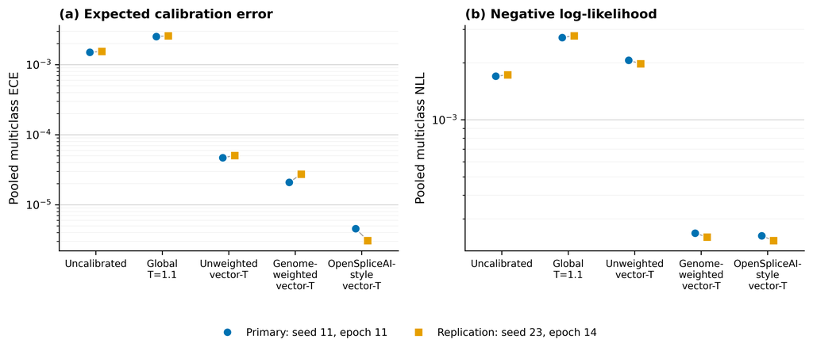

**Figure 1. Five-chromosome calibration transfer across independently trained flank-400 models.** Pooled multiclass ECE (a) and NLL (b) are shown for the validation-selected seed-11/epoch-11 primary model and seed-23/epoch-14 replication over chr1, chr3, chr5, chr7, and chr9 (416,140,000 evaluated positions per model). Gray segments pair the two training runs within each calibration method. Both axes use logarithmic scales; lower values indicate better calibration. OpenSpliceAI-style vector temperature scaling achieved the lowest pooled ECE and NLL in both runs, while genome-prior-weighted vector scaling also improved both metrics.

## Calibration under the wrong prior can be misleading

In the five-chromosome primary analysis, unweighted vector scaling reduced ECE from 1.507e-03 to 4.692e-05 but increased NLL from 1.698e-03 to 2.062e-03. The replication showed the same disagreement: ECE fell from 1.545e-03 to 5.049e-05 while NLL increased from 1.726e-03 to 1.975e-03. Thus, ECE alone is insufficient and the target prior must be declared.

Fixed global temperature scaling (T=1.1) also worsened both metrics in both trained models. A positive scalar temperature preserves multiclass argmax ordering, so this deterioration cannot be detected from argmax counts alone.

## Argmax and threshold behavior

Calibration changed the probability scale even when ranking changed little. Consequently, thresholds were not transferred unchanged between uncalibrated, globally scaled, and vector-scaled outputs. Threshold-specific precision and recall were treated as operating-point analyses, and no universal threshold was inferred. The unweighted-vector result further shows why argmax counts and ECE cannot be interpreted alone: a method can appear favorable on one summary while assigning worse likelihood to the observed labels under the target population.

## Bootstrap, reliability, and prior sensitivity

Within-model bootstrap resampling and reliability diagrams supported the conclusion that prior-compatible vector scaling improved probability alignment relative to the uncalibrated model. The independent seed-23 model and five-chromosome evaluation provide the separate training-run and transfer check; position-level bootstrap intervals are not interpreted as training-seed uncertainty.

Prior-sensitivity analysis provided a mechanistic explanation: as the validation non-splice weight approached the target-position weight, target-prior NLL and ECE improved and excessive splice argmax counts decreased. The flank-80 analyses are retained as a context comparison rather than as the primary flank-400 evidence.

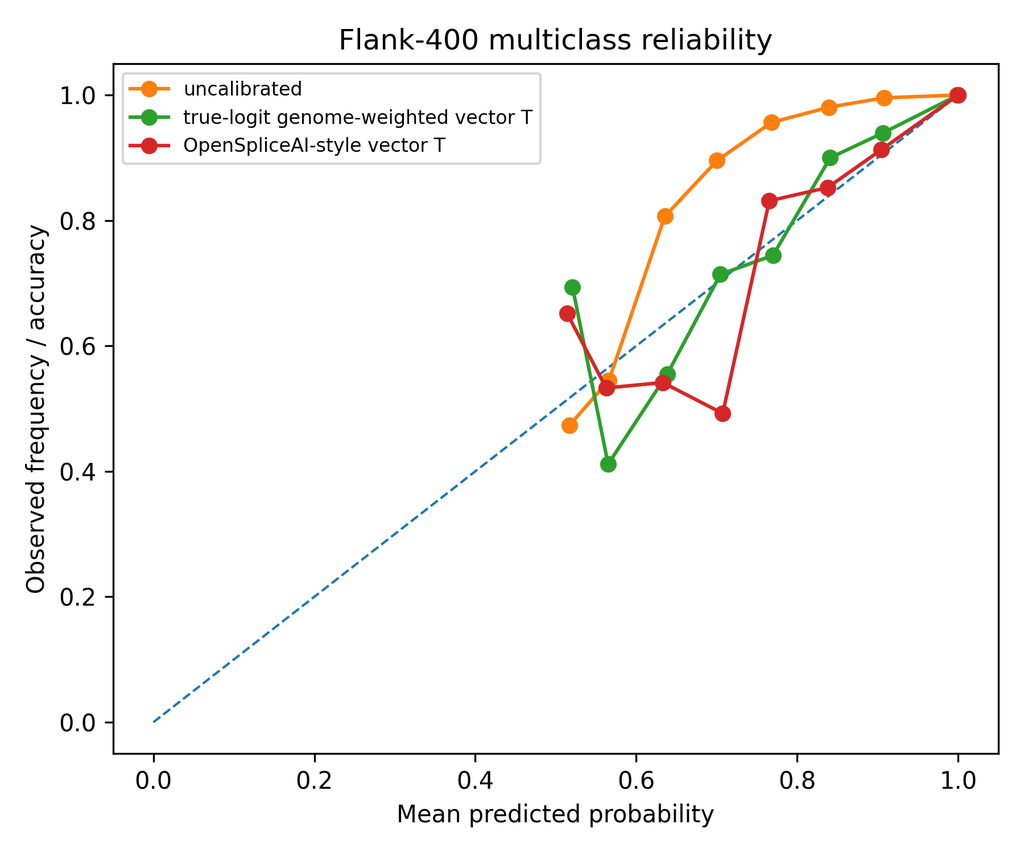

Multiclass reliability for seed-11/epoch-11.

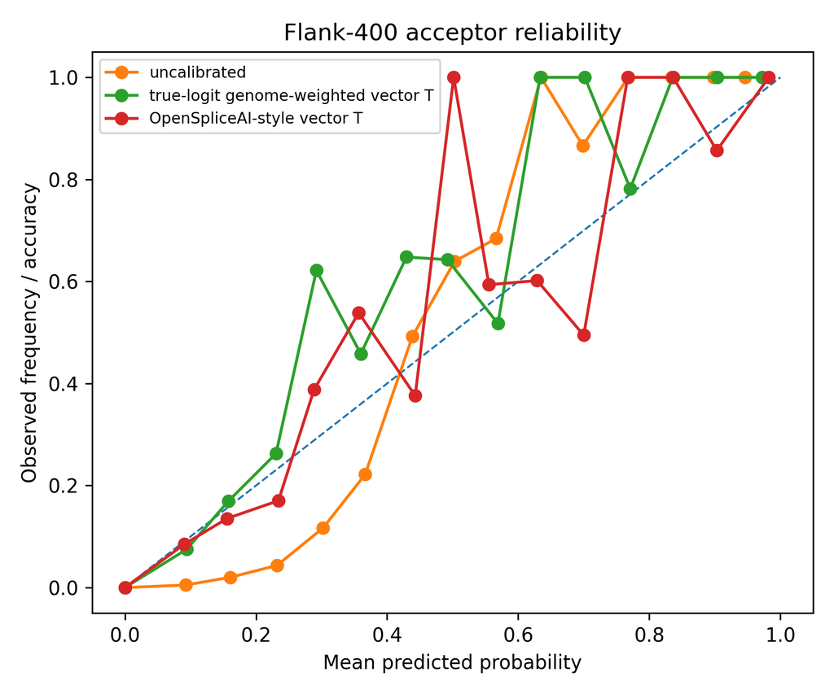

Acceptor reliability for seed-11/epoch-11.

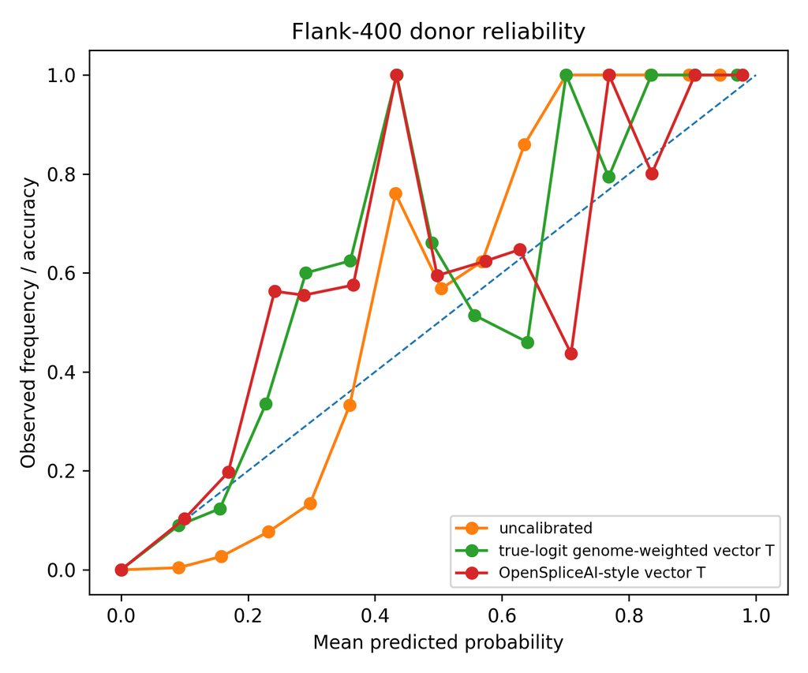

Donor reliability for seed-11/epoch-11.

## Summary of results

Across both validation-selected flank-400 models, OpenSpliceAI-style vector temperature scaling achieved the lowest pooled ECE and NLL, while genome-prior-weighted vector scaling also improved both metrics. Unweighted fitting produced low ECE but worse NLL, and fixed global scaling worsened both metrics. Agreement across five test chromosomes and two independently trained models shows that the qualitative result was not created by negative subsampling or a single training run.

# Discussion

## Detection and calibration answer different questions

The primary finding is not a new splice-site detector or a new temperature-scaling algorithm. It is that detection and calibrated probability estimation answer different questions under extreme genomic imbalance. The validation-selected flank-400 models achieved very strong splice-site ranking on sampled-cache analyses, while their uncalibrated probabilities remained less suitable under the target-position population than either prior-compatible vector calibration procedure.

Ranking can remain nearly unchanged while probability interpretation changes substantially. A low calibrated splice probability does not necessarily imply that a site is irrelevant for discovery; it may reflect the rarity of splice sites in the target position population. Candidate discovery should therefore use AUPRC, top-k summaries, or validated operating thresholds rather than assuming that multiclass argmax or an arbitrary probability cutoff is appropriate.

## Calibration is conditional on a target population

Calibration is not an intrinsic property of a model independent of data. A predictor may be calibrated for one annotation, prior, or evaluation population and miscalibrated for another. In this study, “target prior” refers to all sequence positions across the GRCh38/MANE evaluation H5 gene/transcript records. It does not refer to every intergenic base in complete chromosomes or to noncanonical, cryptic, variant-altered, or tissue-specific splice sites.

This distinction explains why unweighted vector scaling can optimize the splice-enriched sampled task while performing poorly under target-position NLL. Importance weighting changes the calibration objective to match the intended evaluation population. The OpenSpliceAI-style full-validation baseline targets the same natural validation distribution without relying on the sampled calibration cache, explaining its strong performance.

## Interpretation of the OpenSpliceAI-style comparison

The local OpenSpliceAI-style vector-temperature baseline had the lowest pooled ECE and NLL in both independently trained flank-400 models. This should not be described as our method beating OpenSpliceAI calibration or as a benchmark against every published OpenSpliceAI model. The supported contribution is the explicit prior-aware comparison and evaluation framework. The five-chromosome comparisons are descriptive replications, not an inferential test of superiority over chromosomes.

## Practical implications

Probability thresholds should be chosen only after calibration and under the intended target population. Fixed threshold transfer across uncalibrated, globally scaled, and vector-scaled outputs can materially change precision and recall. When the downstream task is candidate discovery, ranking metrics may remain the most useful summary. When probabilities are used for risk interpretation or decision support, the calibration population and label definition must be documented.

## Limitations

The main flank-400 calibration pattern replicated in a second independently trained model, reducing dependence on a single checkpoint. Nevertheless, two validation-selected training runs do not fully characterize optimization variability, and the five evaluated chromosomes should not be treated as randomly sampled replicate units.

Neither configuration is a full SpliceAI-10k ensemble or a claim of state-of-the-art detection. The flank-80/flank-400 comparison also does not isolate the causal effect of context length.

The target population covers sequence positions represented in the MANE gene/transcript evaluation H5. Five-chromosome streaming removes negative subsampling for those records, but it is not complete intergenic whole-genome inference. Calibration is also not demonstrated for all isoforms, noncanonical or cryptic sites, variant-altered sequences, or tissue-specific splice usage.

The OpenSpliceAI-style baseline was implemented locally to reproduce its class-wise vector-temperature behavior. We compare calibration protocols and objectives rather than every published OpenSpliceAI model. Finally, post-hoc calibration does not separately quantify epistemic and aleatoric uncertainty.

## Conclusion

Across two independently trained focal-loss OpenSpliceAI-style flank-400 models, strong splice-site detection did not guarantee calibrated target-prior probabilities. Streaming 416,140,000 sequence positions across five test chromosomes per model reproduced the calibration ordering: OpenSpliceAI-style vector temperature scaling achieved the lowest pooled ECE and NLL, while genome-prior-weighted vector scaling also sharply improved both metrics. Unweighted vector scaling reduced ECE but worsened NLL, demonstrating that a small ECE alone does not establish better probability quality. Splice-site probabilities should therefore be evaluated and interpreted relative to an explicit target population, separately from detection performance.

# References

Barash, Yoseph, John A. Calarco, Weijun Gao, Qun Pan, Xinchen Wang, Ofer Shai, Benjamin J. Blencowe, and Brendan J. Frey. 2010. “Deciphering the Splicing Code.” *Nature* 465: 53–59. https://doi.org/10.1038/nature09000.

Bretschneider, Hannes, Shreshth Gandhi, Amit G. Deshwar, Khalid Zuberi, and Brendan J. Frey. 2018. “COSSMO: Predicting Competitive Alternative Splice Site Selection Using Deep Learning.” *Bioinformatics* 34 (13): i429–37. https://doi.org/10.1093/bioinformatics/bty244.

Chao, Kuan-Hao, Alan Mao, Anqi Liu, Steven L. Salzberg, and Mihaela Pertea. 2025. “OpenSpliceAI: An Efficient, Modular Implementation of SpliceAI Enabling Easy Retraining on Non-Human Species.” *eLife* 14: RP107454. https://doi.org/10.7554/eLife.107454.2.

Guo, Chuan, Geoff Pleiss, Yu Sun, and Kilian Q. Weinberger. 2017. “On Calibration of Modern Neural Networks.” In *Proceedings of the 34th International Conference on Machine Learning*, 70:1321–30. Proceedings of Machine Learning Research.

Jaganathan, Kishore, Sofia Kyriazopoulou Panagiotopoulou, Jeremy F. McRae, Siavash Fazel Darbandi, David Knowles, Yang I. Li, Jack A. Kosmicki, et al. 2019. “Predicting Splicing from Primary Sequence with Deep Learning.” *Cell* 176 (3): 535–548.e24. https://doi.org/10.1016/j.cell.2018.12.015.

Kull, Meelis, Miquel Perello-Nieto, Markus Kängsepp, Telmo Silva Filho, Hao Song, and Peter Flach. 2019. “Beyond Temperature Scaling: Obtaining Well-Calibrated Multiclass Probabilities with Dirichlet Calibration.” In *Advances in Neural Information Processing Systems*. Vol. 32.

Lin, Tsung-Yi, Priya Goyal, Ross Girshick, Kaiming He, and Piotr Dollár. 2017. “Focal Loss for Dense Object Detection.” In *Proceedings of the IEEE International Conference on Computer Vision*, 2980–88. https://doi.org/10.1109/ICCV.2017.324.

Morales, Joannella, Shashikant Pujar, Jane E. Loveland, Alexander Astashyn, Ruth Bennett, Andrew Berry, Emily Cox, et al. 2022. “A Joint NCBI and EMBL-EBI Transcript Set for Clinical Genomics and Research.” *Nature* 604 (7905): 310–15. https://doi.org/10.1038/s41586-022-04558-8.

Saito, Takaya, and Marc Rehmsmeier. 2015. “The Precision-Recall Plot Is More Informative Than the ROC Plot When Evaluating Binary Classifiers on Imbalanced Datasets.” *PLOS ONE* 10 (3): e0118432. https://doi.org/10.1371/journal.pone.0118432.

Schneider, Valerie A., Tina Graves-Lindsay, Kerstin Howe, Nathan Bouk, Hsiu-Chuan Chen, Paul A. Kitts, Terence D. Murphy, et al. 2017. “Evaluation of GRCh38 and de Novo Haploid Genome Assemblies Demonstrates the Enduring Quality of the Reference Assembly.” *Genome Research* 27 (5): 849–64. https://doi.org/10.1101/gr.213611.116.

Zeng, Tony, and Yang I. Li. 2022. “Predicting RNA Splicing from DNA Sequence Using Pangolin.” *Genome Biology* 23: 103. https://doi.org/10.1186/s13059-022-02664-4.